# Abstract DGEpi 2026

Authors

Affiliations

Paulina Sell

German Environment Agency, Environmental Hygiene, Berlin, Germany

Margaux Sanchez

French National Agency for Food, Environmental and Occupational Health & Safety, Maisons-Alfort, France

Philippe Palmont

French National Agency for Food, Environmental and Occupational Health & Safety, Maisons-Alfort, France

Simon Steiger

Karolinska Institutet, Department of Medicine Solna, Division of Clinical Epidemiology, Stockholm, Sweden

Dietrich Plass

German Environment Agency, Environmental Hygiene, Berlin, Germany

Modified

14 April 2026

<sup>1</sup> German Environment Agency, Environmental Hygiene, Berlin, Germany  
<sup>2</sup> French National Agency for Food, Environmental and Occupational Health & Safety, Maisons-Alfort, France  
<sup>3</sup> Karolinska Institutet, Department of Medicine Solna, Division of Clinical Epidemiology, Stockholm, Sweden

## Information for Authors

- Abstract submission deadline: **April 15, 2026**
- Submission as **oral** or **posters**
- Abstracts have to be submitted in English.
- The length of the abstract is limited to **2,000 characters** (including spaces), the length of the **title to 250 characters** (including spaces).
- Use only common abbreviations as referenced in the [Oxford Dictionary of Abbreviations](https://www.oed.com/information/understanding-entries/abbreviations/?tl=true). If you use your own abbreviations, they must be written out in full the first time they are used.
- The abstract should use the following structure as far as possible: **introduction, methods, results, conclusion/outlook**.
- You can upload a maximum of **two additional files** containing either tables or graphics.
- You can add up to **5 keywords** to your post.
- When preparing your contribution, please make sure that the spelling, grammar, gender and diversity-sensitive language is correct. The contributions will be printed as submitted; there is no proofreading. After submission, contributions can be edited until the end of the abstract submission.
- The posters will be presented as printed version on poster boards on site.
- The authorship will be informed in June 2026. Organisational details will be communicated directly to the authors.
- To present your paper, you must register for the congress for the fee and pay the registration fee in due time.

## Keywords

Meta-analysis  
Evidence synthesis  
Bayesian modeling  
Uncertainty quantification  
Lead exposure

**Topic**: Environmental Epidemiology  
**Method**: Evidence Synthesis and Triangulation

## Abstract

### Quantifying uncertainty: A methodological comparison of Bayesian and frequentist meta-analyses of studies on lead exposure and children’s intelligence quotient

**Introduction**: Uncertainty quantification is central to evidence synthesis for risk assessment and policy-making, but current meta-analytic approaches often fall short in this regard. Bayesian methods provide probabilistic uncertainty quantification. We compared frequentist and Bayesian meta-analytic frameworks, using lead exposure and IQ as a case study.

**Conclusion**: We provide updated pooled estimates for the effect of lead exposure on children’s IQ. The Bayesian framework provides posterior distributions, enabling direct probability statements, for example about exceeding risk thresholds, and comparative assessments across pollutants. These features are of particular value regarding risk assessment and policy-making.

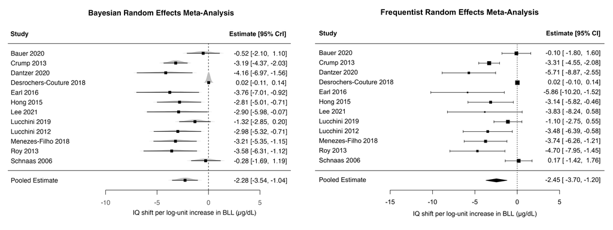

Fig. 1: Forest plots for Bayesian (left) and frequentist (right) meta-analyses. BLL, blood lead level; CI, confidence interval; CrI, credible interval